DIADEM course "Deep Learning - Image Classification & objects detection" -- Mai 20-21, 2026 - v1.1  
CC BY-SA 4.0 Jean-Luc CHARLES (Jean-Luc.charles@mailo.com)

The question of Reproducibility  
in Supervised Learning

In this notebook we use a simple Dense Neural Network (DNN) model  
to focus on the reproducibility of the training process.

# Preliminaries

## Import the Python modules

```python
import os
# suppress tensorflow verbose warnings
os.environ['TF_CPP_MIN_LOG_LEVEL'] = '2'

# Deep Learning modules:
import tensorflow as tf
from tensorflow import keras

# General modules:
import numpy as np
import matplotlib.pyplot as plt
from time import time
from pathlib import Path
from cpuinfo import get_cpu_info
import GPUtil
import sys

# local modules:
from utils.tools import elapsed_time_since, cpu_gpu, plot_loss_accuracy
```

[output not shown]

```python
print(f"Python    : {sys.version.split()[0]}")
print(f"tensorflow: {tf.__version__} with keras {keras.__version__}")
print(f"numpy     : {np.__version__}")
```

```
Python    : 3.12.12
tensorflow: 2.17.0 with keras 3.14.1
numpy     : 1.26.4
```

## Global settings:

```python
# To visualize the graphs directly in the cell of the Notebook
%matplotlib inline

# SEED will be used to set the "seed" of the random generators in order
# to have repeatable random numbers
SEED = 1234

# Ask tensorflow to display only ERROR messages;
tf.get_logger().setLevel('ERROR')
```

## Check wether GPU is available for tensorflow or not:

```python
gpus = tf.config.list_physical_devices('GPU')
if gpus:
    print(f"tensorflow running on {len(gpus)} GPU(s):")
    for gpu in gpus:
        print(f"  - {gpu.name}")
        # configure tensorflow to dynamically allocate GPU memory as needed:
        tf.config.experimental.set_memory_growth(gpu, True)
else:
    print("tensorflow running on CPU.")
```

```
tensorflow running on CPU.
```

```
2026-05-18 13:47:50.502085: E external/local_xla/xla/stream_executor/cuda/cuda_driver.cc:266] failed call to cuInit: CUDA_ERROR_NO_DEVICE: no CUDA-capable device is detected
```

## Create the `model` directory

```python
print(f'{"WORKING DIRECTORY":17s}: {Path.cwd()}')

model_dir = Path("./model")
model_dir.mkdir(exist_ok=True)
print(f'{"MODEL DIRECTORY":17s}: {model_dir.absolute()}')
```

```
WORKING DIRECTORY: /home/jlc/work/IA-MachineLearning/18-DIADEM/DIADEM_DL/Classification/Notebooks
MODEL DIRECTORY  : /home/jlc/work/IA-MachineLearning/18-DIADEM/DIADEM_DL/Classification/Notebooks/model
```

# 1 - Prepare the MNIST dataset

## 1.1 Load the MNIST dataset (images and labels)

We use the keras `load_data` function to load the data from the MNIST (see [tf.keras.datasets.mnist.load_data](https://www.tensorflow.org/api_docs/python/tf/keras/datasets/mnist/load_data)):

- `train_img`, `train_lab` are the training images and labels,
- `valid_img`, `valid_lab` are the validation images and labels.

```python
(train_img, train_lab), (valid_img, valid_lab) = keras.datasets.mnist.load_data()
```

Let's check the `shape` and `dtype` attributes of the numpy arrays:

```python
print(f"train_img.shape: {train_img.shape}, dtype: {train_img.dtype}")
print(f"train_lab.shape: {train_lab.shape}, dtype: {train_lab.dtype}")
print(f"valid_img.shape: {valid_img.shape}, dtype: {valid_img.dtype}")
print(f"lab_vaild.shape: {valid_lab.shape}, dtype: {valid_lab.dtype}")
```

```
train_img.shape: (60000, 28, 28), dtype: uint8
train_lab.shape: (60000,), dtype: uint8
valid_img.shape: (10000, 28, 28), dtype: uint8
lab_vaild.shape: (10000,), dtype: uint8
```

To avoid long computation time, we take only 1000 images & labels in the training dataset  
and 200 images & labels in the validation dataset.

```python
train_img = train_img[:1000]
valid_img = valid_img[:200]

train_lab = train_lab[:1000]
valid_lab = valid_lab[:200]

print(f'{train_img.shape=}')
print(f'{valid_img.shape=}')
```

```
train_img.shape=(1000, 28, 28)
valid_img.shape=(200, 28, 28)
```

## 1.2 Display images and labels:

#### Simple display of a MNIST image with the plt.plot function

```python
plt.figure(figsize=(1,1))
plt.imshow(train_img[199], cmap='gray')
plt.axis('off');
```

[output not shown]

#### Display images on a grid with labels

```python
from utils.tools import display_image
help(display_image)
```

```
Help on function display_image in module utils.tools:

display_image(image_array: numpy.ndarray, RC: tuple, start: int = 0, figsize: tuple = None, label_array: numpy.ndarray = None, reverse: bool = False, ret: bool = False)
    To display images from image_array on a R x C grid, starting at rank r.

    Parameters:
      image_array: the array of images
      RC           the tuple (rows, columns) of the image grid
      start        the starting rank in the array image_array (default: 0)
      figsize      the sise of the display (default: (C//2+1, R//2+1))
      label_array  an optional array of labels to give the imshow title
      reverse      wether to reverse video the image or not (default: False)
      ret          wether to return the fig or not (useful for marimo)
```

With the display_image function, print a grid of 4 x 10 images, starting at the rank you want, with the display of the image labels:

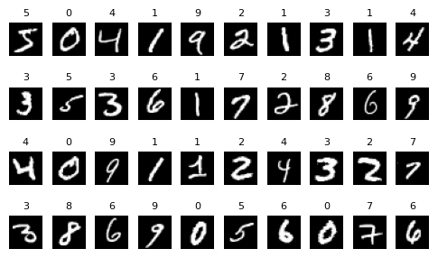

```python
display_image(train_img, (4,10), label_array=train_lab)
```

## 1.5 - Define global parameters

To avoid hard-coding global parameters such as the number of train/valid/test images, or the size of the images, these parameters are retrieved from the data set:

- with the shape attribute of the `train_img` and `test_im` arrays
- with the size attribute of the first training image for example...

Complete the cell below to define useful global parameters:

```python
NB_TRAIN_IMG = train_img.shape[0]  # number of training images
NB_VALID_IMG = valid_img.shape[0]  # number of validation images
NB_PIXEL     = train_img[0].size   # number of elements (pixels) of the firts training image:
NB_CLASS     = len(set(train_lab)) # number of classes:
```

```python
# check:
print(f"{NB_TRAIN_IMG} training images, {NB_VALID_IMG} validation images")
print(f"{train_img.shape[1]}x{train_img.shape[2]}={NB_PIXEL} pixels in each image")
print(f"{NB_CLASS} classes found in the `train_lab` ndarray")
```

```
1000 training images, 200 validation images
28x28=784 pixels in each image
10 classes found in the `train_lab` ndarray
```

# 2 - Process input data

Two treatments must be applied to the data from the MNIST database:

- **on images**: convert the matrices of 28$\,\times\,$28 pixels (`uint8`integers) into **normalized** vectors $(V_i)_{i=0..783}$ of 784 real values $V_i$ with $ 0 \leqslant V_i \leqslant 1$;
- **on labels**: transform integers into *one-hot* vectors.

## 2.1 - Transform input matrices into normalized vectors

We define the arrays `x_train`, `x_valid` containing the matrices of the arrays `train_img`, `valid_img` *flattened* to normalized vectors (values between 0 and 1):

```python
x_train = train_img.reshape(NB_TRAIN_IMG, NB_PIXEL)/255
x_valid = valid_img.reshape(NB_VALID_IMG, NB_PIXEL)/255
```

Check the shape, min and max of x_train and x_valid :

```python
print(f'train: {x_train.shape}, min: {x_train.min()}, max: {x_train.max()}')
print(f'valid: {x_valid.shape}, min: {x_valid.min()}, max: {x_valid.max()}')
```

```
train: (1000, 784), min: 0.0, max: 1.0
valid: (200, 784), min: 0.0, max: 1.0
```

## 2.2 - *one-hot* encoding of labels

We use the **tf.keras** `to_categorical` function (see [tf.keras.utils.to_categorical](https://www.tensorflow.org/api_docs/python/tf/keras/utils/to_categorical)) to define the `y_train` and `y_valid` arrays containing the *hot-one* encoded version of `train_lab` and `valid_lab`:

```python
from tensorflow.keras.utils import to_categorical

# 'one-hot' encoding' of labels :
y_train = to_categorical(train_lab)
y_valid = to_categorical(valid_lab)
```

Print the first 10 values of train_lab and y_train :

```python
print(train_lab[:10])
print(y_train[:10])
```

```
[5 0 4 1 9 2 1 3 1 4]
[[0. 0. 0. 0. 0. 1. 0. 0. 0. 0.]
 [1. 0. 0. 0. 0. 0. 0. 0. 0. 0.]
 [0. 0. 0. 0. 1. 0. 0. 0. 0. 0.]
 [0. 1. 0. 0. 0. 0. 0. 0. 0. 0.]
 [0. 0. 0. 0. 0. 0. 0. 0. 0. 1.]
 [0. 0. 1. 0. 0. 0. 0. 0. 0. 0.]
 [0. 1. 0. 0. 0. 0. 0. 0. 0. 0.]
 [0. 0. 0. 1. 0. 0. 0. 0. 0. 0.]
 [0. 1. 0. 0. 0. 0. 0. 0. 0. 0.]
 [0. 0. 0. 0. 1. 0. 0. 0. 0. 0.]]
```

# 3 - Build the Dense Neural Network (DNN)

Now we build a simple **Dense Neural Network** to classify the MNIST images.  
Of course, this is not the "state of the art" : convolutive NN, transformers have much more impressive scores to classify images,  
but we just want want a simple model easy to understand with short training computation time.  
We build this simple DNN:

- an **input layer** of 784 values (the pixel matrices of the 28 $\times$ 28 MNIST images flattened into normalized vectors of 784 `float` numbers),
- a **hidden layer** of 784 neurons using the `relu` activation function,
- an **output layer** of 10 neurons, for the classification of the 10 digits {0,1,2...9}, using the `softmax` activation function required for classifying.

[figure not shown]

[image: JLC]

For the sake of convenience we défine a parameterized function to build the DNN:

```python
from tensorflow.keras.models import Sequential
from tensorflow.keras.layers import Dense, Input, Dropout

def build_DNN(nb_input, nb_neuron, nb_class, seed=None, name=''):

    if seed is not None:
        ##########################
        # Deterministic training #
        ##########################
        # 1/ set the seed of the random generators used by tensorflow:
        tf.keras.utils.set_random_seed(seed)
        # 2/ make the tf ops determinisctic
        # [see https://blog.tensorflow.org/2022/05/whats-new-in-tensorflow-29.html]
        tf.config.experimental.enable_op_determinism()

    model = Sequential()
    model.add(Input(shape=(nb_input,), name='input'))               # INPUT layer
    model.add(Dense(nb_neuron, activation='relu', name='h1'))       # HIDDEN layer
    model.add(Dense(nb_class, activation='softmax', name='output')) # OUTPUT layer

    model.compile(loss='categorical_crossentropy',   # the loss function
                  optimizer='adam',                  # the SGD algorithm
                  metrics=['accuracy'])              # training returns accuracy and loss values

    if name: model.name = name
    return model
```

Complete the cell below:  
- Define model , the neural network created with a call to build_NN without giving any seed,  
- Display infos on the model with a call to model.summary .

```python
NB_NEURON = NB_PIXEL

# we pass global parameters to the "build_NN" function:
model = build_DNN(NB_PIXEL, NB_NEURON, NB_CLASS)

# Display a summary on the model properties:
model.summary()
```

```
Model: "sequential"
```

```
┏━━━━━━━━━━━━━━━━━━━━━━━━━━━━━━━━━┳━━━━━━━━━━━━━━━━━━━━━━━━┳━━━━━━━━━━━━━━━┓
┃ Layer (type)                    ┃ Output Shape           ┃       Param # ┃
┡━━━━━━━━━━━━━━━━━━━━━━━━━━━━━━━━━╇━━━━━━━━━━━━━━━━━━━━━━━━╇━━━━━━━━━━━━━━━┩
│ h1 (Dense)                      │ (None, 784)            │       615,440 │
├─────────────────────────────────┼────────────────────────┼───────────────┤
│ output (Dense)                  │ (None, 10)             │         7,850 │
└─────────────────────────────────┴────────────────────────┴───────────────┘
```

```
 Total params: 623,290 (2.38 MB)
```

```
 Trainable params: 623,290 (2.38 MB)
```

```
 Non-trainable params: 0 (0.00 B)
```

# 4 - Elementary tests of the reproducibility of the model training...

The training of a neural network is a stochastic process: perfect reproducibility of the training may be difficult to achieve...  
To highlight the question of reproducibility we run simple loops of trainings with different strategies:  
$\leadsto$ at each lap loop: built the model (no SEED), train once & evaluat the model  
$\leadsto$ built & save (weights) the model (no SEED) once, then at each lap loop: load the model weights, train once & evaluate  
$\leadsto$ built & save the model (no SEED) once, then at each lap loop: load the full model (structure & weights), train once & evaluate  
$\leadsto$ at each lap loop: built the model (SEED fixed), train once & evaluate  
$\leadsto$ built & save the model (SEED fixed) once, then at each lap loop: load the full model, train once and evaluate

### 4.1 Build the model (no SEED) at each training: not reproducible

We build the model without seed before each training:

```python
print(cpu_gpu())
for _ in range(5):
    model = build_DNN(NB_PIXEL, NB_NEURON, NB_CLASS)  # Build a new model without setting seed
    model.fit(x_train, y_train, epochs=1, batch_size=32, validation_data=(x_valid, y_valid), verbose=2)
```

```
CPU [11th Gen Intel(R) Core(TM) i7-1165G7 @ 2.80GHz]
32/32 - 1s - 21ms/step - accuracy: 0.7010 - loss: 1.0041 - val_accuracy: 0.8550 - val_loss: 0.4888
32/32 - 1s - 19ms/step - accuracy: 0.7080 - loss: 0.9709 - val_accuracy: 0.8150 - val_loss: 0.5478
32/32 - 1s - 19ms/step - accuracy: 0.7140 - loss: 1.0118 - val_accuracy: 0.8550 - val_loss: 0.4894
32/32 - 1s - 18ms/step - accuracy: 0.6850 - loss: 1.0441 - val_accuracy: 0.8400 - val_loss: 0.5214
32/32 - 1s - 18ms/step - accuracy: 0.6800 - loss: 1.0710 - val_accuracy: 0.8000 - val_loss: 0.5716
```

The metrics are close together but not exactly the same.  
$\leadsto$ This is particularly problematic for `val_accuracy` and `val_loss` used to evaluate the training after each epoch 🙁.

### 4.2 Build and save the model weights (no SEED), then load the model weights at each training: not reproducible

We build the model without seed, save its weights:

```python
model = build_DNN(NB_PIXEL, NB_NEURON, NB_CLASS)
model.save_weights('model/DNN_noseed.weights.h5')
```

and then load the model weights before each training:

```python
print(cpu_gpu())
for _ in range(5):
    model.load_weights('model/DNN_noseed.weights.h5') # reload the inital model weights
    hist = model.fit(x_train, y_train, epochs=1, batch_size=32, validation_data=(x_valid, y_valid), verbose=2)
```

```
CPU [11th Gen Intel(R) Core(TM) i7-1165G7 @ 2.80GHz]
32/32 - 1s - 23ms/step - accuracy: 0.7150 - loss: 0.9743 - val_accuracy: 0.8450 - val_loss: 0.4958
32/32 - 0s - 5ms/step - accuracy: 0.7130 - loss: 1.0518 - val_accuracy: 0.8000 - val_loss: 0.5348
```

```
32/32 - 0s - 5ms/step - accuracy: 0.7210 - loss: 1.0518 - val_accuracy: 0.8250 - val_loss: 0.5184
32/32 - 0s - 5ms/step - accuracy: 0.7110 - loss: 1.0482 - val_accuracy: 0.8650 - val_loss: 0.4573
32/32 - 0s - 5ms/step - accuracy: 0.7090 - loss: 1.0648 - val_accuracy: 0.8250 - val_loss: 0.5551
```

The training is still non-reproducible 😟

### 4.3 Build and save the full model (no SEED) then load the full model at each training: not reproducible

We save the **structure** & **weights** of a model built without setting the seed:

```python
model = build_DNN(NB_PIXEL, NB_NEURON, NB_CLASS)
model.save('model/DNN_noseed.keras')
```

Now we load the full model (structure & weights) before each training:

```python
print(cpu_gpu())
for _ in range(5):
    model = tf.keras.models.load_model('model/DNN_noseed.keras') # reload the inital model weights
    hist = model.fit(x_train, y_train, epochs=1, batch_size=32, validation_data=(x_valid, y_valid), verbose=2)
```

```
CPU [11th Gen Intel(R) Core(TM) i7-1165G7 @ 2.80GHz]
32/32 - 1s - 16ms/step - accuracy: 0.7180 - loss: 0.9937 - val_accuracy: 0.8700 - val_loss: 0.5024
32/32 - 1s - 16ms/step - accuracy: 0.6960 - loss: 1.0137 - val_accuracy: 0.8100 - val_loss: 0.5530
32/32 - 0s - 15ms/step - accuracy: 0.6960 - loss: 1.0438 - val_accuracy: 0.7950 - val_loss: 0.5756
32/32 - 0s - 15ms/step - accuracy: 0.6810 - loss: 1.0598 - val_accuracy: 0.7950 - val_loss: 0.5848
32/32 - 1s - 16ms/step - accuracy: 0.6950 - loss: 1.0153 - val_accuracy: 0.8350 - val_loss: 0.5047
```

The training is still non-reproducible 😟

### 4.4 Build the model (SEED fixed) at each training: reproducible

Now we build the model with the **same fixed seed** at each training:

```python
print(cpu_gpu())
for _ in range(5):
    model = build_DNN(NB_PIXEL, NB_NEURON, NB_CLASS, seed=1234)  # Build a new model with seed set
    hist = model.fit(x_train, y_train, epochs=1, batch_size=32, validation_data=(x_valid, y_valid), verbose=2)
```

```
CPU [11th Gen Intel(R) Core(TM) i7-1165G7 @ 2.80GHz]
32/32 - 1s - 19ms/step - accuracy: 0.7170 - loss: 0.9627 - val_accuracy: 0.8650 - val_loss: 0.4894
32/32 - 1s - 18ms/step - accuracy: 0.7170 - loss: 0.9627 - val_accuracy: 0.8650 - val_loss: 0.4894
32/32 - 1s - 19ms/step - accuracy: 0.7170 - loss: 0.9627 - val_accuracy: 0.8650 - val_loss: 0.4894
32/32 - 1s - 19ms/step - accuracy: 0.7170 - loss: 0.9627 - val_accuracy: 0.8650 - val_loss: 0.4894
32/32 - 1s - 19ms/step - accuracy: 0.7170 - loss: 0.9627 - val_accuracy: 0.8650 - val_loss: 0.4894
```

If we set the seed to the same value when building the model the 4 training metrics are perfectly reproducible 😃.

### 4.5 Build and save the full model (SEED fixed), then load the full model at each training: reproducible

To save some computing work, we can try to build the model with a fixed seed only once, save the full model (structure & weights) and just load the full initial model (structure & weights) before each training:

```python
model = build_DNN(NB_PIXEL, NB_NEURON, NB_CLASS, seed=1234)
model.save('model/DNN_seed-1234.keras')
```

```python
print(cpu_gpu())
for _ in range(5):
    model = tf.keras.models.load_model('model/DNN_seed-1234.keras') # reload the model structure & weights
    hist = model.fit(x_train, y_train, epochs=1, batch_size=32, validation_data=(x_valid, y_valid), verbose=2)
```

```
CPU [11th Gen Intel(R) Core(TM) i7-1165G7 @ 2.80GHz]
32/32 - 1s - 22ms/step - accuracy: 0.7170 - loss: 0.9627 - val_accuracy: 0.8650 - val_loss: 0.4894
32/32 - 1s - 17ms/step - accuracy: 0.7170 - loss: 0.9627 - val_accuracy: 0.8650 - val_loss: 0.4894
32/32 - 1s - 16ms/step - accuracy: 0.7170 - loss: 0.9627 - val_accuracy: 0.8650 - val_loss: 0.4894
32/32 - 1s - 16ms/step - accuracy: 0.7170 - loss: 0.9627 - val_accuracy: 0.8650 - val_loss: 0.4894
32/32 - 1s - 16ms/step - accuracy: 0.7170 - loss: 0.9627 - val_accuracy: 0.8650 - val_loss: 0.4894
```

OK, the successive traings are reproducible 😃  
What if we build again the model later (for example, we re-run the notebook after closing it)?

```python
model = build_DNN(NB_PIXEL, NB_NEURON, NB_CLASS, seed=1234)
model.save('model/DNN_seed-1234.keras')
```

```python
print(cpu_gpu())
for _ in range(5):
    model = tf.keras.models.load_model('model/DNN_seed-1234.keras') # reload the model structure & weights
    hist = model.fit(x_train, y_train, epochs=1, batch_size=32, validation_data=(x_valid, y_valid), verbose=2)
```

```
CPU [11th Gen Intel(R) Core(TM) i7-1165G7 @ 2.80GHz]
32/32 - 1s - 17ms/step - accuracy: 0.7170 - loss: 0.9627 - val_accuracy: 0.8650 - val_loss: 0.4894
32/32 - 1s - 18ms/step - accuracy: 0.7170 - loss: 0.9627 - val_accuracy: 0.8650 - val_loss: 0.4894
32/32 - 1s - 16ms/step - accuracy: 0.7170 - loss: 0.9627 - val_accuracy: 0.8650 - val_loss: 0.4894
32/32 - 1s - 16ms/step - accuracy: 0.7170 - loss: 0.9627 - val_accuracy: 0.8650 - val_loss: 0.4894
32/32 - 1s - 17ms/step - accuracy: 0.7170 - loss: 0.9627 - val_accuracy: 0.8650 - val_loss: 0.4894
```

As far as the seed is set to the same value, the 4 training metrics remain reproducible and keep their values 🤩.

## Conclusion

To ensure the reproducibility of the training we can:  
$\leadsto$ **set the seed** when building the model (and everywhere else where required)  
$\leadsto$ Save the full model (**structure & weights**)  
$\leadsto$ Load the **full model** (structure and weights) with the *tf.keras.models.load_model* function befor each training.

# 5 - Reproducibility of the full taining of the model...

Now let's see how to apply the previous results (elementary test, only 1 epoch of training) to a complete training over several epochs.

## 5.1 - Build a new model (no SEED) before each training of 15 epochs: not reproducible

Complete the cell below to write a loop that runs the following steps 5 times:  
- Define model , the neural network created by a call to build_DNN without specifying a value for the seed  
- Add to the list H the data returned by the call to model.fit over 15 epochs, with a batch size of 32 (you can also pass the argument verbose=0 to reduce the displayed infos).

```python
H  = []       # to store each traing metrics
t0 = time()   # start chrono...

print(f"Loop ", end="")
for i in range(5):
    print(f" #{i+1}", end="")

    # build a new model at each loop lap, no SEED given
    model = build_DNN(NB_PIXEL, NB_NEURON, NB_CLASS)

    # train the model:
    hist = model.fit(x_train, y_train, # images, labels
                     epochs=15,        # the total number of successive trainings
                     batch_size=32,    # split the whole dadaset in batches
                     validation_data=(x_valid, y_valid),
                     verbose=0)
    H.append(hist)

print(f' Total Train {elapsed_time_since(t0)}')
```

```
Loop  #1 #2 #3 #4 #5 Total Train Elapsed time 14s -> 00:00:14
```

To plot accuracy & loss versus epochs we use the `plot_loss_accuracy` function from the local `utils.tools` module.

Let's plot the accuracy & loss curves for training and evaluation with the legends of the 5 plots:

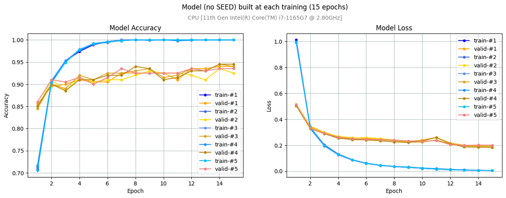

```python
plot_loss_accuracy(H, message='Model (no SEED) built at each training (15 epochs)', single_legend=False)
```

Now we plot only validation accuracy & loss versus epochs with the legends of the 5 plots:

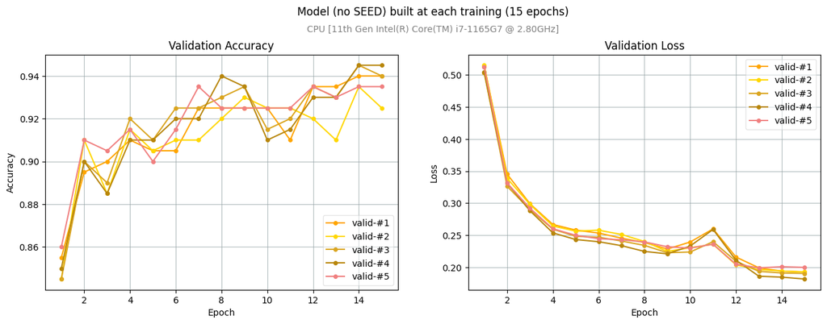

```python
plot_loss_accuracy(H, message='Model (no SEED) built at each training (15 epochs)', plot_train=False, single_legend=False)
```

The `val_accuracy` and `val_loss` curves differ for each of the trainings.  
$\leadsto$ It is a problem when we train the model with the **early stoppping** extension: the training would stop at a different epoch if we run the training many times.

## 5.2 -Build a new model (fixed SEED) befor each training of 15 epochs: reproducible

Complete the cell below to write a loop that runs the following steps 5 times:  
- Define model , the neural network created by a call to build_DNN with the argument seed=1234  
- Add to the list H the data returned by the call to model.fit over 15 epochs, with a batch size of 32 (you can also pass the argument verbose=0 to reduce the displayed infos).

```python
H  = []       # to store each traing metrics
t0 = time()   # start chrono...

print(f"Loop ", end="")
for i in range(5):
    print(f" #{i+1}", end="")

    # build a new model with a fixed SEED:
    model = build_DNN(NB_PIXEL, NB_NEURON, NB_CLASS, seed=1234)

    # train the model:
    hist = model.fit(x_train, y_train, # images, labels
                     epochs=15,        # the total number of successive trainings
                     batch_size=32,    # split of the whole dadaset in batches
                     validation_data=(x_valid, y_valid),
                     verbose=0)
    H.append(hist)

print(f' Total Train {elapsed_time_since(t0)}')
```

```
Loop  #1 #2 #3 #4 #5 Total Train Elapsed time 14s -> 00:00:14
```

Let's plot the accuracy & loss curves for training and evaluation:

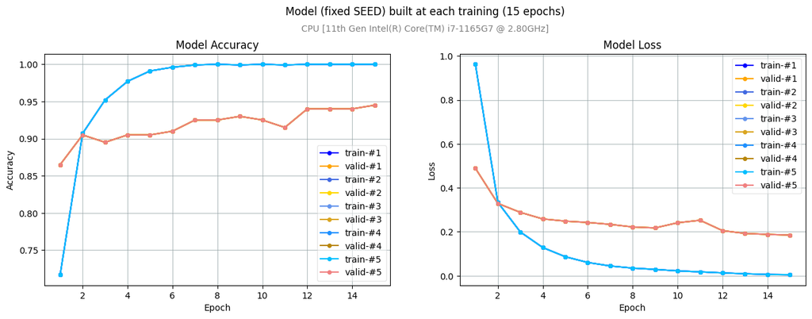

```python
plot_loss_accuracy(H, message='Model (fixed SEED) built at each training (15 epochs)', single_legend=False)
```

$\leadsto$ the repoducibility is perfect 😃

## 5.3 - Build and save the model (fixed SEED) once, then load the model for each training (15 epochs): reproducible

To save some computing work, we can build the model with a fixed seed once, save it (structure & weights) and then reload the full initial model (structure & weights) before each training:

Complete the cell below:  
- Define model , the neural network created by a call to build_DNN includind the argument seed=1234  
- Save the model with a call to model.save giving 'model/DNN_seed-1234.keras' as the name of file

```python
model = build_DNN(NB_PIXEL, NB_NEURON, NB_CLASS, seed=1234)
model.save('model/DNN_seed-1234.keras')
```

Complete the cell below to write a loop that runs the following steps 5 times:  
- Define model by loading the previous model file with a call to tf.keras.models.load_model  
- Add to the list H the data returned by the call to model.fit over 15 epochs, with a batch size of 32 (you can also pass the argument verbose=0 to reduce the displayed infos).

```python
H  = []       # to store each traing metrics
t0 = time()   # start chrono...

print(f"Loop ", end="")
for i in range(5):
    print(f" #{i+1}", end="")

    # reload the initial model structure & weights :
    model = tf.keras.models.load_model('model/DNN_seed-1234.keras')

    # train the network
    hist = model.fit(x_train, y_train,
                     epochs=15,
                     batch_size=32,
                     validation_data=(x_valid, y_valid),
                     verbose=0)
    H.append(hist)

print(f' Total Train {elapsed_time_since(t0)}')
```

```
Loop  #1 #2 #3 #4 #5 Total Train Elapsed time 13s -> 00:00:13
```

Let's plot the accuracy & loss curves for training and evaluation:

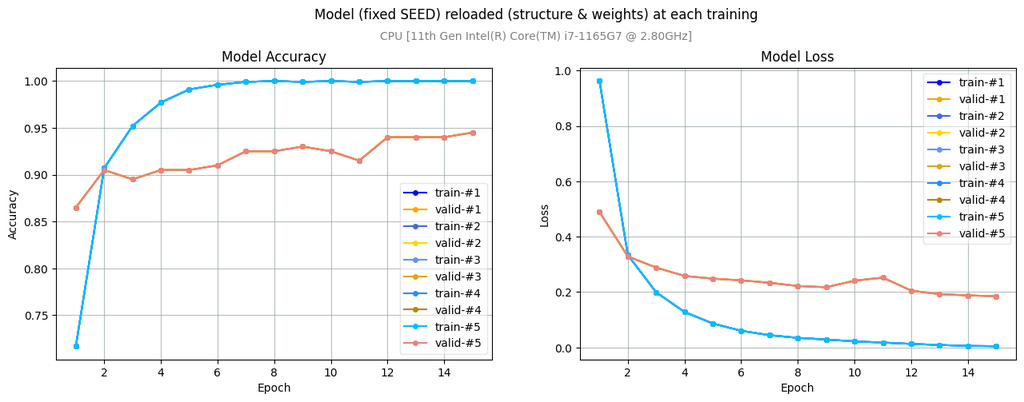

```python
plot_loss_accuracy(H, message='Model (fixed SEED) reloaded (structure & weights) at each training', single_legend=False)
```

$\leadsto$ the repoducibility is perfect 😃

# Conclusion

What you have learned in this notebook:

- How to load the MNIST databank with the **keras** module
- How to pre-process and check the input dataset before the training
- Why are there issues to get reproducible trainings and what are the solutions

$\leadsto$ in the next notebook *02-Trainning_evaluation.ipynb*, you will learn how to evaluate the performance  
of a trained model and how to apply regularization techniques to avoid overfit.